# ISA 401: Business Intelligence & Data Visualization

## 21: Time Series, Spatial & Spatiotemporal Charts

### Fall 2026

# Before We Start

1 Join today's Zoom

Use the Zoom link in the [**Week 0 Module**](https://miamioh.instructure.com/courses/258169/modules/981092) on Canvas. **Mute** your mic and **turn off** your video.  
There is no R to write today. Have Tableau and Power BI open if you want to follow the demos.

2 Today's plan

**Part 1. Time:** line charts, calendar plots, and animated charts.  
**Part 2. Space:** choropleths, cartograms, and symbol maps, with last night's election maps.  
**Part 3. Space and time:** spatiotemporal maps, then a Tableau demo.

# Learning Objectives

By the end of today, you should be able to:

1. **Choose** a chart for change over time: a line chart, a calendar plot, or an animated chart.

2. **Explain** the different types of spatial plots.

3. **Select** suitable spatial graphs for different scenarios.

4. **Understand** how spatiotemporal plots can help in storytelling (what makes BI special).

# Part 1: Time

## Charts for Time Series Data

# Recall: Our Line Chart in Tableau

[figure not shown]

**Time series data:** comparable measurements recorded over time. The line joins each day to the next, so the eye reads the shape: waves, and a peak on Jan 15, 2022. From March 2022 the line turns into a comb: Ohio began reporting once a week, so a line chart also shows **how the data were collected**.

# Line or Bars? It Depends on the Question

[figure not shown]

Use a line when

there are many, evenly spaced time points and the **shape** is the message: trend, seasonality, peaks.

It is possible to use bars when

there are a few periods and each period's **total** is the message, like cases per month or sales per quarter.

Use bars when only two points

a line suggests a path you never measured. Two bars (2024 vs 2026) compare the amounts honestly.

# What to Look for in a Line Chart

[figure not shown]

Trend

An increasing or decreasing pattern over time.

Seasonality

REGULAR patterns that repeat at a constant frequency: here, every December.

Cycle

Somewhat irregular rises and falls of unknown duration, like recessions.

**Data:** U.S. Census Bureau, Retail Sales: Clothing and Clothing Accessory Stores [RSCCASN], retrieved from [FRED](https://fred.stlouisfed.org/series/RSCCASN) on November 04, 2026 with `tidyquant::tq_get()`. One line per year makes the seasonal pattern easy to compare.

# Key Takeaway 1

> A **line chart** is the default for a time series: time on the x-axis, and lines that connect moments which really are connected. With only a few periods, **bars** are often clearer.

# Calendar Plots

[figure not shown]

# Bonus: A Calendar Plot in Power BI

Steps

**1.** Get Data → Text/CSV → the file above.

**2.** Insert an **R script visual** and drag `date` and `n` into it.

**3.** Paste the `calendR::calendR()` call from the previous slide, using `dataset$n`.

Why it matters

Power BI has no calendar plot of its own. An R visual lets a dashboard use any chart R can draw, refreshed with the report's data.  
Power BI Desktop needs R installed on the same computer for this to work.

# Hans Rosling: The Best Stats You Have Seen

.panel[Activity

> While watching this video, please answer the questions in the next tab!!

[interactive chart not shown]

.panel[Your Solution

- What data is represented in this visualization? Be specific. ____

- How is each data type visually encoded? ___________

- Do you think the encodings are appropriate? _________

# So What is the Motion Bubble Chart?

> Motion charts are essentially **animated bubble charts**. A bubble chart shows data using the x-axis, y-axis, and the size and color of the bubble. A motion chart displays changes over time by showing movement within the two-dimensional space and changes in the size and color of the bubbles. -- [Juice Analytics](https://www.juiceanalytics.com/writing/better-know-visualization-motion-charts)

**Encoding mechanisms:**

- x-axis is typically used to encode a **numeric variable**
- y-axis is also used to encode a **numeric variable**
- area is used to encode a **numeric/ordinal variable**
- color is typically used to encode a **nominal variable**
- motion/animation is typically used to encode **time**

# An Animated Bubble Chart

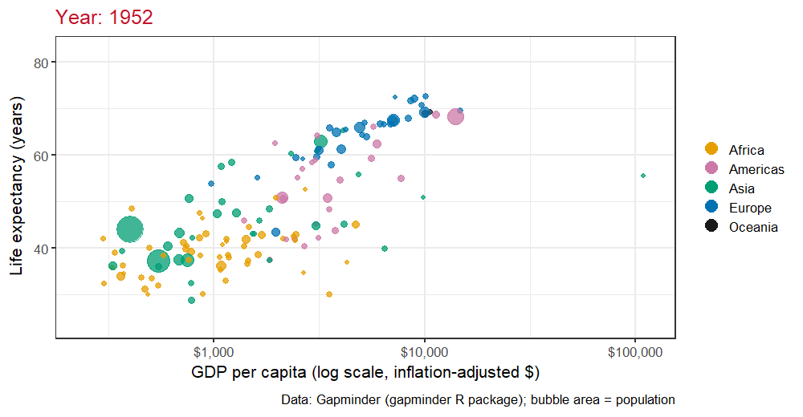

Read it like Rosling

**each bubble:** a country

**x:** GDP per capita (log scale)

**y:** life expectancy

**area:** population

**color:** continent

**motion:** year, 1952 to 2007

**Watch one bubble, then the crowd.** Most countries move up and to the right. Which ones fall back, and when?

# Live Demo: Creating Bubble Charts in Power BI

Let us use Power BI to create a similar chart to the one created by Hans Rosling. We will be using the [gapminder.csv](https://raw.githubusercontent.com/fmegahed/isa401/main/data/gapminder.csv).

[interactive chart not shown]

# Key Takeaway 2

> **Animation** encodes time as time. It is great for telling a story to an audience, but weak for precise comparisons: viewers remember the motion, not the values. Pair it with a static chart when the numbers matter.

# Part 2: Space

## Spatial Plots, with Last Night's Election Maps

# Choropleth Maps

Maps where areas are **shaded, colored, or patterned** relative to a data attribute value.

[figure not shown]

Charles Dupin's Illiteracy in France Choropleth, created in 1826

# Choropleth Maps

Maps where areas are **shaded, colored, or patterned** relative to a data attribute value.

[interactive chart not shown]

Population Density in U.S.

# Last Night: A Choropleth of House Districts

[interactive chart not shown]

**Source:** [2026 US House Election Results: Live Map](https://abcnews.com/Elections/2026-us-house-election-results-live-map/), ABC News (live map; it updates as races are called).

**Every district elects one member, but not every district gets the same ink.** Large rural districts fill most of the map; dense city districts are specks.

**Compare the colors with the seat count** above the map. Who looks like they are winning? Who is?

# Ohio Last Night: What Does Color Mean?

[interactive chart not shown]

**Source:** [Ohio Governor Results](https://abcnews.com/widgets/generalstateresults?chamber=governor&source=story&stateAbbrev=oh&type=general&year=2026), ABC News (live map; it updates as races are called).

Nominal (this map)

Distinct hues for categories with no order: the party or candidate in the lead.

Sequential

Light to dark for one quantity: turnout, population density, cases per 100K.

Diverging

Two hues that meet at a meaningful middle: a **50-50** race. Shade would show the size of the lead.

# Cartograms

A cartogram is a map in which **areas are scaled and distorted relative to a data
attribute value**

[figure not shown]

The First Cartogram – Emile Levasseur, 1868

# Cartograms

A cartogram is a map in which **areas are scaled and distorted relative to a data attribute value**

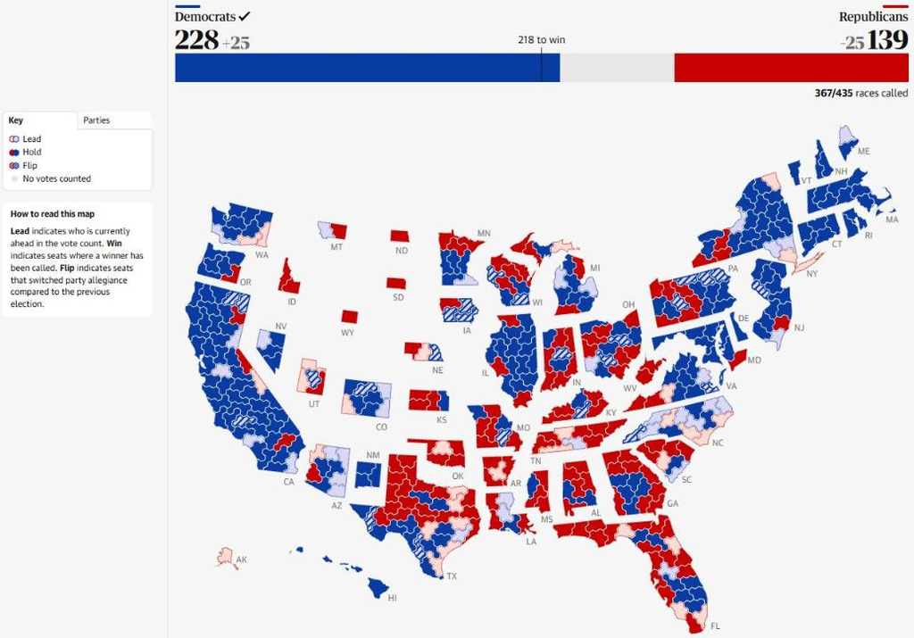

**Every district gets the same ink.** Compare it with the ABC district map: same races, but here area encodes seats, not land.

**Source:** [US midterm elections 2026: live results](https://www.theguardian.com/us-news/ng-interactive/2026/nov/03/midterm-elections-full-results-senate-house-governor-races), The Guardian; cartogram by The Downballot. Snapshot taken 5:40 AM ET, Nov 4, 2026, while votes were still being counted.

# Proportional Symbols Map

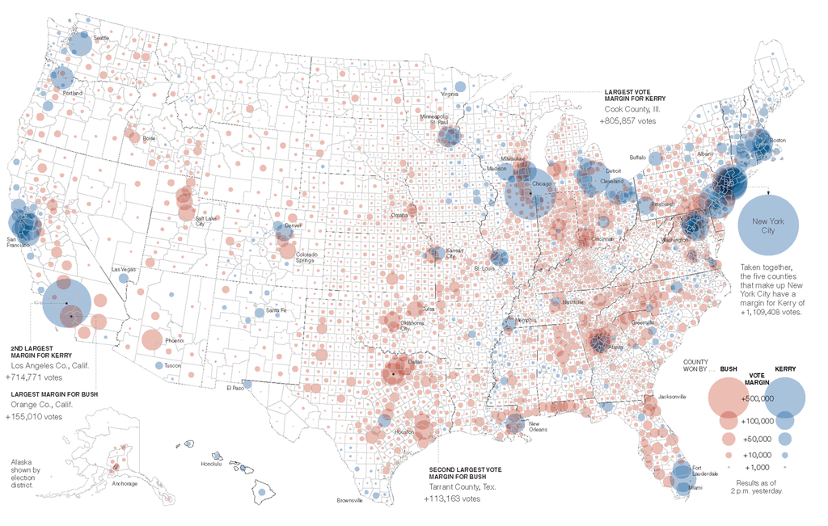

**Source:** The New York Times, coverage of the 2004 presidential election (Bush vs. Kerry).

**The land stays put; a symbol carries the data.** The symbol's size (or an arrow's length) is the amount, and its color or direction is the category.

# Proportional Symbols Map

[figure not shown]

The NYT's U.S. Coverage of 2009 Super Bowl

# Key Takeaway 3

> Pick the map by what **area** should mean. In a **choropleth**, area is land and color is the data. In a **cartogram**, area is the data. In a **symbol map**, the land stays put and the symbol's size is the data.

# Part 3: Space and Time

## Spatiotemporal Maps

# Spatiotemporal Maps

[figure not shown]

A visualization of car crashes in the Cincinnati metro area

# Spatiotemporal Maps

[figure not shown]

COVID vaccination rates per county as reported by the CDC

# Exploring the Cincy Crashes Dataset

Let us use Tableau to explore the [cincy_2025_crashes.csv](https://raw.githubusercontent.com/fmegahed/isa401/main/data/cincy_2025_crashes.csv), where we will create the following:

- A calculated field titled `unique_count`

- A plot of the total number of unique crashes per day

- A table of number of unique crashes by week day

- An animated symbols map

# Recap

# Summary of Main Points

- Use a line chart for a time series, bars for a few periods, a calendar plot for daily patterns, and animation to tell a story over time

- Explain the different types of spatial plots

- Select suitable spatial graphs for different scenarios

- Understand how spatiotemporal plots can help in storytelling (what makes BI special)

# Before Next Class

**Monday, Nov 9:** we start with **Race Call**, a phone game on today's charts, so bring your phone. Then Visualizing High-Dimensional Data, picking up from the motion bubble chart (six variables at once).

Suggested

Wilke, *Fundamentals of Data Visualization*: [**ch. 13, Visualizing time series**](https://clauswilke.com/dataviz/time-series.html).

Free online. Lines, points, and when to connect them.

Wilke: [**ch. 15, Visualizing geospatial data**](https://clauswilke.com/dataviz/geospatial-data.html).

Projections, choropleths, and cartograms.

Skim if curious

Rosling (2006). [**The best stats you've ever seen**](https://www.ted.com/talks/hans_rosling_the_best_stats_you_ve_ever_seen). TED.

The whole talk, not just the part we watched.

[**Gapminder Tools**](https://www.gapminder.org/tools/).

Play with the bubble chart: change the axes, pick a country, and press play.